# validateE2data

Alex Holcombe

2/27/2018

Optional validation (don’t need to run this), loads raw data on its own and validates a few things

1/3 of trials have 1 target (numTargets==1) targetSide ==0 means targets on both sides

Checking some stuff out

```r
#Loads raw data from MATLAB files for second backwards paper second experiment
require(R.matlab)
mainPath<-".." # to main E2 folder

#Second experiment of second backwards-letters paper. random orientation each frame.
rawDataPath<- file.path(mainPath,
                            "Data/RawData/Data")
#raw data path containing .mat file for each subject

source(file.path("turnMATintoMeltedDataframe.R"))
cat("Here are the files in the raw data directory")
```

```
## Here are the files in the raw data directory
```

```r
dir(rawDataPath)
```

```
##  [1] "AA_17-11-07_1.mat" "AB_17-11-07_1.mat" "AC_17-11-08_1.mat"
##  [4] "AD_17-11-08_1.mat" "AE_17-11-09_1.mat" "AF_17-11-09_1.mat"
##  [7] "AG_17-11-09_1.mat" "AH_17-11-09_1.mat" "AI_17-11-09_1.mat"
## [10] "AJ_17-11-10_1.mat" "AK_17-11-10_1.mat" "AL_17-11-10_1.mat"
## [13] "AM_17-11-10_1.mat" "AN_17-11-10_1.mat" "AO_17-11-30_1.mat"
## [16] "AP_18-01-10_1.mat" "AQ_18-01-12_1.mat" "AR_18-01-12_1.mat"
## [19] "AS_18-01-16_1.mat" "AT_18-01-16_1.mat" "AU_18-01-18_1.mat"
## [22] "AV_18-01-18_1.mat" "AW_18-01-18_1.mat" "AX_18-01-23_1.mat"
## [25] "AY_18-02-01_1.mat" "AZ_18-01-23_1.mat" "BA_18-01-25_1.mat"
## [28] "BB_18-01-25_1.mat" "BC_18-01-25_1.mat" "BD_18-01-30_1.mat"
## [31] "BE_18-01-30_1.mat" "BF_18-02-01_1.mat" "BG_18-02-01_1.mat"
## [34] "BH_18-02-02_1.mat" "BI_18-02-02_1.mat" "BJ_18-02-07_1.mat"
## [37] "BK_18-02-07_1.mat" "BL_18-02-07_1.mat" "BM_18-02-09_1.mat"
## [40] "BN_18-02-09_1.mat" "BO_18-02-09_1.mat" "BP_18-02-13_1.mat"
## [43] "BQ_18-04-04_1.mat" "BR_18-04-04_1.mat" "BS_18-04-06_1.mat"
## [46] "BT_18-04-06_1.mat" "BU_18-04-06_1.mat" "BV_18-04-09_1.mat"
## [49] "BW_18-04-09_1.mat" "BX_18-04-09_1.mat" "BY_18-04-11_1.mat"
## [52] "BZ_18-04-11_1.mat" "CA_18-04-11_1.mat" "CB_18-04-13_1.mat"
## [55] "CC_18-04-18_1.mat" "CD_18-04-18_1.mat" "CE_18-04-18_1.mat"
## [58] "CF_18-04-20_1.mat" "CG_18-04-20_1.mat" "CH_18-04-20_1.mat"
## [61] "CI_18-04-24_1.mat" "CJ_18-04-24_1.mat" "CK_18-04-24_1.mat"
## [64] "CL_18-04-24_1.mat" "CM_18-04-26_1.mat" "CN_18-05-02_1.mat"
## [67] "CO_18-05-04_1.mat" "CP_18-05-04_1.mat" "CQ_18-05-04_1.mat"
## [70] "CR_18-05-08_1.mat" "CS_18-05-08_1.mat" "CT_18-05-08_1.mat"
## [73] "CU_18-05-10_1.mat" "CV_18-05-10_1.mat" "CW_18-05-11_1.mat"
## [76] "CX_18-05-11_1.mat" "CY_18-05-17_1.mat" "CZ_18-05-11_1.mat"
## [79] "DA_18-05-17_1.mat" "DB_18-05-17_1.mat" "Icon\r"
```

```r
readInAllFiles<- function(rawDataPath) {

  files <- dir(path=rawDataPath,pattern='.mat')  #find all data files in this directory
  dfAll<-data.frame()
  for (i in 1:length(files)) { #read in each file
    fileThis<- file.path(rawDataPath,files[i])
    rawDataLoad=tryCatch(
      readMat(fileThis),
      error=function(e) {
        stop( paste0("ERROR reading the file ",fileThis," :",e) )
      } )
    apparentSubjectName <- strsplit(files[i],split="_")[[1]][1]
    subjectName<- rawDataLoad$participantID[[1]]
    if (apparentSubjectName != subjectName) {
      stop( paste0("WARNING apparentSubjectName",apparentSubjectName," from filename does not match subjectName in data structure",subjectName) )
    }
    else { cat(paste0(' Subject ',apparentSubjectName,' read in')) }
    rawDataLoad$file <- files[i]

    dfThis<- turnMATintoMeltedDataframe(rawDataLoad)

    tryCatch(
      dfAll<-rbind(dfAll,dfThis), #if fail to bind new with old,
      error=function(e) { #Give feedback about how the error happened
        cat(paste0("Tried to merge but error:",e) )
      } )
  }
  return(dfAll)
}
```

```r
E<- readInAllFiles(rawDataPath)
```

```
##  Subject AA read in Subject AB read in Subject AC read in Subject AD read in Subject AE read in Subject AF read in Subject AG read in Subject AH read in Subject AI read in Subject AJ read in Subject AK read in Subject AL read in Subject AM read in Subject AN read in Subject AO read in Subject AP …
```

```r
#Calculate the serial position error
E$SPE<- E$respSP - E$targetSP
```

Why are there NaNs for targetSP? Because that’s when only one target (targetSide==1 or ==2)

```r
table(E$subject, E$targetSP,useNA="always")
```

```
##
##         5  6  7  8  9 10 11 12 NaN <NA>
##   AA   55 37 55 32 41 50 44 46  72    0
##   AB   50 41 39 29 39 60 41 61  72    0
##   AC   42 47 48 34 42 51 63 33  72    0
##   AD   42 51 38 52 43 46 40 48  72    0
##   AE   38 41 48 59 40 42 53 39  72    0
##   AF   66 47 32 51 33 40 45 46  72    0
##   AG   37 59 38 42 53 58 32 41  72    0
##   AH   46 42 36 46 49 44 53 44  72    0
##   AI   54 32 29 43 56 54 44 48  72    0
##   AJ   45 44 48 42 51 35 59 36  72    0
##   AK   61 46 49 47 40 35 44 38  72    0
##   AL   41 43 52 34 40 48 47 55  72    0
##   AM   30 36 42 62 60 37 47 46  72    0
##   AN   39 39 43 46 48 38 54 53  72    0
##   AO   37 40 41 48 56 40 50 48  72    0
##   AP   46 39 65 34 40 50 32 54  72    0
##   AQ   46 42 47 38 44 39 42 62  72    0
##   AR   57 49 50 37 39 32 52 44  72    0
##   AS   37 44 49 56 45 44 32 53  72    0
##   AT   52 60 33 30 44 47 42 52  72    0
##   AU   46 36 31 71 43 43 45 45  72    0
##   AV   54 48 36 44 43 54 45 36  72    0
##   AW   30 39 44 40 46 45 53 63  72    0
##   AX   34 43 36 42 52 61 52 40  72    0
##   AY   38 43 57 46 59 46 31 40  72    0
##   AZ   49 49 34 46 55 42 37 48  72    0
##   BA   42 46 35 39 59 41 45 53  72    0
##   BB   34 35 58 29 52 58 47 47  72    0
##   BC   57 50 41 48 35 46 36 47  72    0
##   BD   61 48 36 45 43 38 38 51  72    0
##   BE   35 42 43 35 55 52 50 48  72    0
##   BF   60 49 38 27 32 63 42 49  72    0
##   BG   48 36 38 35 61 56 41 45  72    0
##   BH   37 49 40 58 42 26 40 68  72    0
##   BI   48 35 52 47 51 36 44 47  72    0
##   BJ   45 45 31 46 61 24 53 55  72    0
##   BK   38 51 43 52 42 49 48 37  72    0
##   BL   37 43 53 33 48 37 53 56  72    0
```

[output cut: 28 more lines]

```
##   CO   42 41 47 44 45 47 47 47  72    0
##   CP   36 57 50 61 48 34 44 30  72    0
##   CQ   42 54 53 47 48 27 47 42  72    0
##   CR   34 32 42 40 49 45 70 48  72    0
##   CS   34 47 46 53 45 43 52 40  72    0
##   CT   42 36 53 48 60 49 34 38  72    0
##   CU   44 36 54 49 36 45 48 48  72    0
##   CV   46 32 48 66 43 38 49 38  72    0
##   CW   38 42 38 36 56 51 55 44  72    0
##   CX   27 46 39 39 62 43 42 62  72    0
##   CY   51 42 27 33 58 45 43 61  72    0
##   CZ   57 54 41 42 31 38 49 48  72    0
##   DA   65 29 29 49 43 38 54 53  72    0
##   DB   43 49 46 39 42 45 46 50  72    0
##   <NA>  0  0  0  0  0  0  0  0   0    0
```

Show how targetSP works

```r
library(dplyr)
En <- E
En$letterSeq<- NULL #otherwise can't use dplyr
CU <- En %>% filter(subject=="CU")
table(CU$target,CU$targetSide, useNA="always")
```

```
##
##          0   1   2 <NA>
##   1    144  36  36    0
##   2    144  36  36    0
##   <NA>   0   0   0    0
```

```r
#targetSide ==0  means targets on both sides
table(CU$targetSide, CU$targetSP, useNA="always")
```

```
##
##         5  6  7  8  9 10 11 12 NaN <NA>
##   0    36 28 38 38 32 36 40 40   0    0
##   1     3  6  9  4  1  5  4  4  36    0
##   2     5  2  7  7  3  4  4  4  36    0
##   <NA>  0  0  0  0  0  0  0  0   0    0
```

The below works now that turnMATintoMeltedDataframe takes care of the list elements

```r
#CUall <- E[ ,E$subject=="CU" ]
CUall <- E %>% filter(subject=="CU")
i<- E$subject == "CU"
E[i,] #previously didn't work. You can't slice a dataframe that has a list (letterSeq) as a member.
```

```
## # A tibble: 432 x 16
##    trial target condition subject respSP numTargets targetSide letterSeq
##    <int>  <int>     <dbl> <chr>    <int>      <dbl>      <dbl> <list>
##  1     1      1         1 CU          10          2          0 <dbl [16]>
##  2     2      1         1 CU          NA          1          2 <dbl [16]>
##  3     3      1         2 CU           5          2          0 <dbl [16]>
##  4     4      1         2 CU           9          2          0 <dbl [16]>
##  5     5      1         1 CU           6          2          0 <dbl [16]>
##  6     6      1         2 CU           7          1          1 <dbl [16]>
##  7     7      1         2 CU           5          2          0 <dbl [16]>
##  8     8      1         2 CU           2          1          1 <dbl [16]>
##  9     9      1         1 CU           6          2          0 <dbl [16]>
## 10    10      1         1 CU           8          2          0 <dbl [16]>
## # ... with 422 more rows, and 8 more variables:
## #   targetStreamOrientations <list>, targetSP <dbl>, targetOrient <dbl>,
## #   resp <dbl>, respOrient <dbl>, respOrder <dbl>, allRTs <dbl>, SPE <dbl>
```

```r
subset(E, subject=="CU")
```

```
## # A tibble: 432 x 16
##    trial target condition subject respSP numTargets targetSide letterSeq
##    <int>  <int>     <dbl> <chr>    <int>      <dbl>      <dbl> <list>
##  1     1      1         1 CU          10          2          0 <dbl [16]>
##  2     2      1         1 CU          NA          1          2 <dbl [16]>
##  3     3      1         2 CU           5          2          0 <dbl [16]>
##  4     4      1         2 CU           9          2          0 <dbl [16]>
##  5     5      1         1 CU           6          2          0 <dbl [16]>
##  6     6      1         2 CU           7          1          1 <dbl [16]>
##  7     7      1         2 CU           5          2          0 <dbl [16]>
##  8     8      1         2 CU           2          1          1 <dbl [16]>
##  9     9      1         1 CU           6          2          0 <dbl [16]>
## 10    10      1         1 CU           8          2          0 <dbl [16]>
## # ... with 422 more rows, and 8 more variables:
## #   targetStreamOrientations <list>, targetSP <dbl>, targetOrient <dbl>,
## #   resp <dbl>, respOrient <dbl>, respOrder <dbl>, allRTs <dbl>, SPE <dbl>
```

```r
j<- En$subject == "CU"
EnCU<- En[j,]
```

Load in one file and inspect it

```r
source(file.path("turnMATintoMeltedDataframe.R"))

fileThis<- file.path(rawDataPath, "CU_18-05-10_1.mat")

rawDat=tryCatch(
  readMat(fileThis),
  error=function(e) {
    stop( paste0("ERROR reading the file ",fileThis," :",e) )
  } )
str(rawDat)
```

```
## List of 17
##  $ randomSeed             : num [1, 1] 207945
##  $ participantID          : chr [1, 1] "CU"
##  $ letterSeparation       : num [1, 1] 8.49
##  $ letterEccentricity     : num [1, 1] 6
##  $ allConditions          : num [1, 1:216] 1 1 2 2 1 2 2 2 1 1 ...
##  $ numTargets             : num [1, 1:216] 2 1 2 2 2 1 2 1 2 2 ...
##  $ targetSide             : num [1, 1:216] 0 2 0 0 0 1 0 1 0 0 ...
##  $ itemRate               : num [1, 1] 8
##  $ allLetterOrder         : num [1:216, 1:2, 1:16] 13 6 9 1 10 16 11 1 12 8 ...
##  $ allLetterOrientations  : num [1:216, 1:16] 1 0 1 0 0 0 1 0 1 0 ...
##  $ allTargets             : num [1:216, 1:2] 5 NaN 6 8 7 7 6 6 6 8 ...
##  $ allTargetOrientations  : num [1:216, 1:2] 0 NaN 1 1 0 1 1 1 0 0 ...
##  $ allResponses           : num [1:216, 1:2] 9 NaN 1 3 5 11 5 3 8 11 ...
##  $ allResponseOrientations: num [1:216, 1:2] 0 NaN 0 0 0 1 0 0 0 0 ...
##  $ allResponseOrder       : num [1:216, 1] 2 2 1 2 2 1 2 1 1 1 ...
##  $ allRTs                 : num [1:216, 1:2] 12.78 NaN 1.81 6.19 10.19 ...
##  $ endTime                : num [1, 1] 737190
##  - attr(*, "header")=List of 3
##   ..$ description: chr "MATLAB 5.0 MAT-file, Platform: MACI64, Created on: Thu May 10 11:50:42 2018                                         "
##   ..$ version    : chr "5"
##   ..$ endian     : chr "little"
```

```r
CUmelted<- turnMATintoMeltedDataframe(rawDat)
```

Somehow, what would seem to be the second trial has NaN for lots of stuff

$ allLetterOrder : num [1:216, 1:2, 1:16] 13 6 9 1 10 16 11 1 12 8 … $ allLetterOrientations : num [1:216, 1:16] 1 0 1 0 0 0 1 0 1 0 … $ allTargets : num [1:216, 1:2] 5 NaN 6 8 7 7 6 6 6 8 … $ allTargetOrientations : num [1:216, 1:2] 0 NaN 1 1 0 1 1 1 0 0 … $ allResponses : num [1:216, 1:2] 9 NaN 1 3 5 11 5 3 8 11 … $ allResponseOrientations: num [1:216, 1:2] 0 NaN 0 0 0 1 0 0 0 0 … $ allResponseOrder : num [1:216, 1] 2 2 1 2 2 1 2 1 1 1 … $ allRTs : num [1:216, 1:2] 12.78 NaN 1.81 6.19 10.19 …

Inspect another one

```r
fileThis<- file.path(rawDataPath, "BC_18-01-25_1.mat")

rawDat=tryCatch(
  readMat(fileThis),
  error=function(e) {
    stop( paste0("ERROR reading the file ",fileThis," :",e) )
  } )
str(rawDat)
```

```
## List of 17
##  $ randomSeed             : num [1, 1] 207318
##  $ participantID          : chr [1, 1] "BC"
##  $ letterSeparation       : num [1, 1] 8.49
##  $ letterEccentricity     : num [1, 1] 6
##  $ allConditions          : num [1, 1:216] 1 1 1 2 1 1 1 2 2 1 ...
##  $ numTargets             : num [1, 1:216] 1 2 1 1 1 2 2 1 1 2 ...
##  $ targetSide             : num [1, 1:216] 2 0 2 2 1 0 0 2 2 0 ...
##  $ itemRate               : num [1, 1] 8
##  $ allLetterOrder         : num [1:216, 1:2, 1:16] 1 9 6 1 6 11 15 1 7 9 ...
##  $ allLetterOrientations  : num [1:216, 1:16] 0 0 1 1 0 0 1 1 0 0 ...
##  $ allTargets             : num [1:216, 1:2] NaN 11 NaN NaN 10 5 10 NaN NaN 11 ...
##  $ allTargetOrientations  : num [1:216, 1:2] NaN 0 NaN NaN 0 0 0 NaN NaN 0 ...
##  $ allResponses           : num [1:216, 1:2] NaN 8 NaN NaN 1 9 4 NaN NaN 6 ...
##  $ allResponseOrientations: num [1:216, 1:2] NaN 0 NaN NaN 0 0 0 NaN NaN 0 ...
##  $ allResponseOrder       : num [1:216, 1] 2 2 2 2 1 1 1 2 2 1 ...
##  $ allRTs                 : num [1:216, 1:2] NaN 6.96 NaN NaN 2.22 ...
##  $ endTime                : num [1, 1] 737086
##  - attr(*, "header")=List of 3
##   ..$ description: chr "MATLAB 5.0 MAT-file, Platform: MACI64, Created on: Thu Jan 25 15:49:52 2018                                         "
##   ..$ version    : chr "5"
##   ..$ endian     : chr "little"
```

Sanity visual check that see histogram.

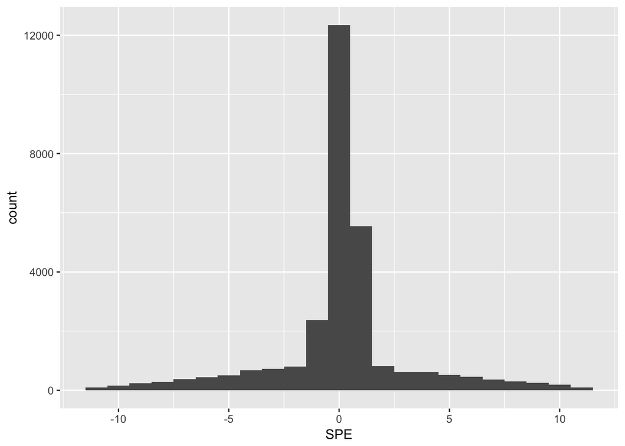

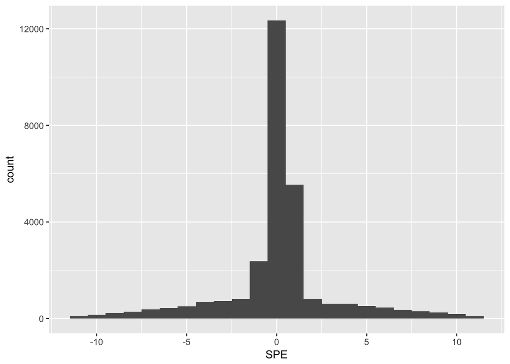

```r
sanityVisualCheck<-TRUE
if (sanityVisualCheck) {
  library(ggplot2)
  g=ggplot(E, aes(x=SPE))
  #plot data
  g<-g+geom_histogram(binwidth=1)
  show(g)

  h<-ggplot(E,aes(x=SPE)) + geom_histogram(binwidth=1)
  show(h)
}
```

Meaning of condition variable * 1 - upright * 2 - inverted

Make condition names more sensible - stream (Left/Right) and orientation (Canonical/Inverted)

```r
E2<- E
names(E2)[names(E2) == 'target'] <-'stream'
names(E2)[names(E2) == 'condition'] <-'orientation'
E2$stream[ E2$stream==1 ] <- "Left"
E2$stream[ E2$stream==2 ] <- "Right"
#mutate condition to Orientation
E2$orientation[ E2$orientation==1 ] <- "Canonical"
E2$orientation[ E2$orientation==2 ] <- "Inverted"
```

Sanity-check some data by graphing.

Investigate whether pathological identicalness of inverted/canonical happens, that happened in E1 . Seems it doesn’t

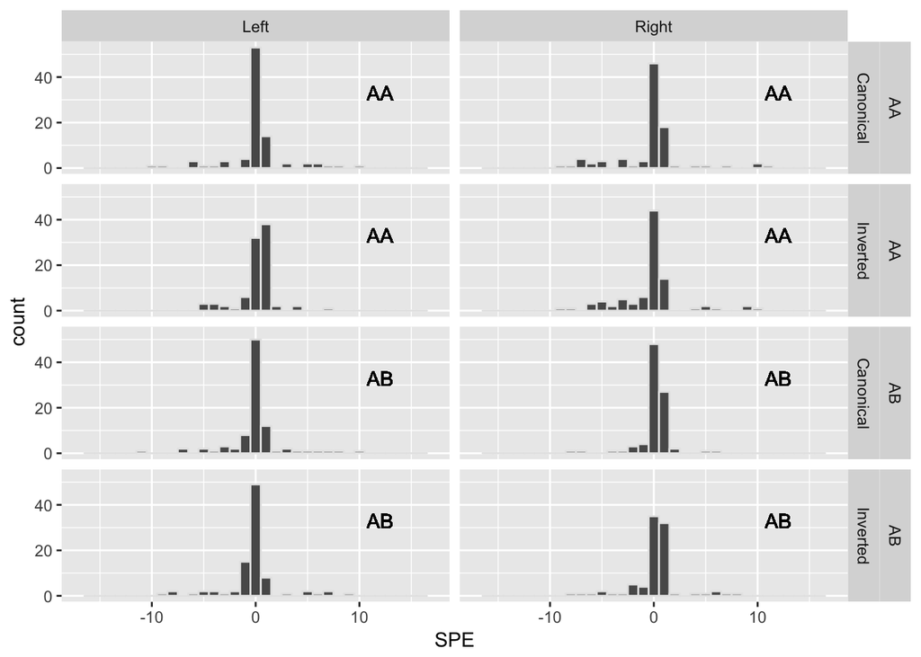

```r
dg<- E2 %>% filter(subject < "AC")

library(ggplot2)
g=ggplot(dg, aes(x=SPE)) + facet_grid(subject+orientation~stream) #,  scales="free_y")
minSPE<- -17; maxSPE<- 17  #But it's 16 items in stream, so shouldn't it be -15, +15?
g<-g+geom_histogram(binwidth=1,color="grey90") + xlim(minSPE,maxSPE)
g<-g+ geom_text(x=12, y= 33, aes(label = subject)) #inset subject name/number. Unfortunately it overwrites itself a million times
show(g)
```

Save data

```r
#save dataframe into proper library data directory
backwards2_E2<-E2
saveRDS(backwards2_E2, file = "../Data/backwards2E2_rawDataFromMAT.rda", compress="bzip2")
```

Look at 1-target performance, understand that variable better because didn’t exist in previous experiment I think.

The first table printed below could easily fool you into thinking that stream (Left, Right) and targetSide (1,2) are not consistent. We think that’s because it records something for both sides (stream variable) even when there is only 1 target (targetSide == 1 or 2 rather than 0, which means two targets).

I Disaggregated allLetterOrientations - done by importE2data.Rmd which renames it targetStreamOrientations

Also maybe give targetSide values that make more common sense, like “dual”, “left”, and “right”

```r
library(dplyr)
E2$letterSeq <- NULL
one <- E2 %>% filter(numTargets==1)

table(one$stream,one$targetSide,useNA="always")
```

```
##
##            1    2 <NA>
##   Left  2880 2880    0
##   Right 2880 2880    0
##   <NA>     0    0    0
```

```r
table(E2$stream,E2$targetSide,E2$numTargets, useNA="always")
```

```
## , ,  = 1
##
##
##             0     1     2  <NA>
##   Left      0  2880  2880     0
##   Right     0  2880  2880     0
##   <NA>      0     0     0     0
##
## , ,  = 2
##
##
##             0     1     2  <NA>
##   Left  11520     0     0     0
##   Right 11520     0     0     0
##   <NA>      0     0     0     0
##
## , ,  = NA
##
##
##             0     1     2  <NA>
##   Left      0     0     0     0
##   Right     0     0     0     0
##   <NA>      0     0     0     0
```

```r
table(one$stream,one$targetSide,one$orientation,useNA="always")
```

```
## , ,  = Canonical
##
##
##            1    2 <NA>
##   Left  1440 1440    0
##   Right 1440 1440    0
##   <NA>     0    0    0
##
## , ,  = Inverted
##
##
##            1    2 <NA>
##   Left  1440 1440    0
##   Right 1440 1440    0
##   <NA>     0    0    0
##
## , ,  = NA
##
##
##            1    2 <NA>
##   Left     0    0    0
##   Right    0    0    0
##   <NA>     0    0    0
```

```r
#table(one$stream,one$targetSide,one$allResponseOrientations,useNA="always")
```